# RM Quiz3

Varun Boodram

October 28, 2014

### Question 1

Load the cell segmentation data from the AppliedPredictiveModeling package using the commands:

```r
library(AppliedPredictiveModeling)
data(segmentationOriginal)
library(caret); library(rattle)
```

1. Subset the data to a training set and testing set based on the Case variable in the data set.

```r
training<-segmentationOriginal[segmentationOriginal$Case=="Train",]
# note that this could also be accomplished by the followng dplyr command:
# (https://github.com/jaeddy/practicalMlCourse/blob/master/code/quiz3.R)
# training <- segmentationOriginal %>%
#    filter(Case == "Train")
testing<-segmentationOriginal[segmentationOriginal$case=="Test",]
```

2. Set the seed to 125 and fit a CART model with the rpart method using all predictor variables and default caret settings.

```r
set.seed(125)
cartModel<-train(Class ~ ., data = training, method = "rpart")
cartModel$finalModel
```

```
## n= 1009
##
## node), split, n, loss, yval, (yprob)
##       * denotes terminal node
##
## 1) root 1009 373 PS (0.63033 0.36967)
##   2) TotalIntenCh2< 4.532e+04 454  34 PS (0.92511 0.07489) *
##   3) TotalIntenCh2>=4.532e+04 555 216 WS (0.38919 0.61081)
##     6) FiberWidthCh1< 9.673 154  47 PS (0.69481 0.30519) *
##     7) FiberWidthCh1>=9.673 401 109 WS (0.27182 0.72818) *
```

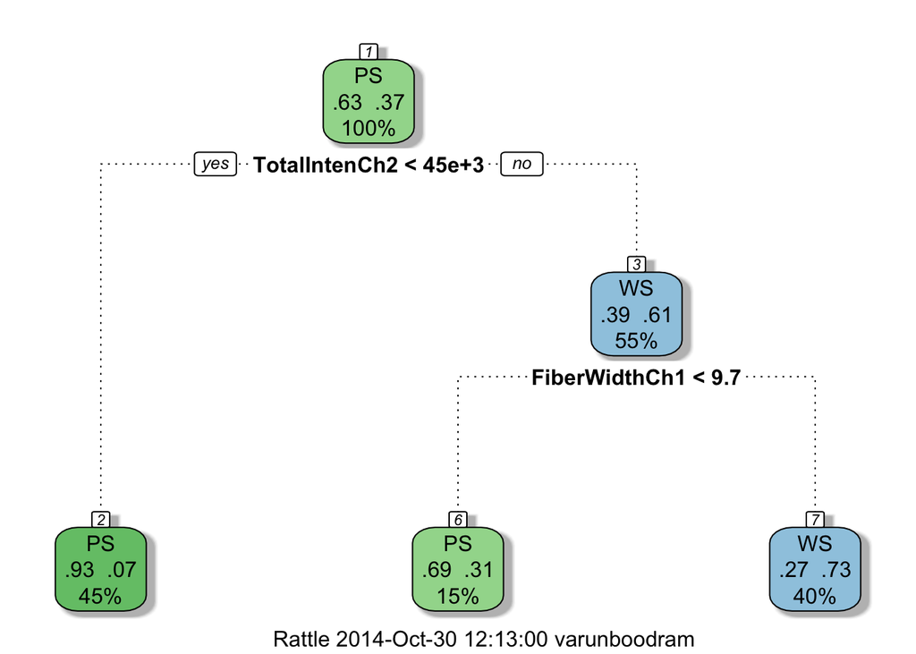

```r
fancyRpartPlot(cartModel$finalModel)
```

3. In the final model what would be the final model prediction for cases with the following variable values:
1. TotalIntench2 = 23,000; FiberWidthCh1 = 10; PerimStatusCh1=2
2. TotalIntench2 = 50,000; FiberWidthCh1 = 10;VarIntenCh4 = 100
3. TotalIntench2 = 57,000; FiberWidthCh1 = 8;VarIntenCh4 = 100
4. FiberWidthCh1 = 8;VarIntenCh4 = 100; PerimStatusCh1=2

Examine each branch in the tree with the information

```r
newSamples <- data.frame(TotalIntench2 = c(23000, 50000, 57000, NA),
                         FiberWidthCh1 = c(10, 10, 8, 8),
                         PerimStatusCh1 = c(2, NA, NA, 2),
                         VarIntenCh4 = c(NA, 100, 100, 100))
rownames(newSamples)<-c("a", "b", "c", "d")
# node 1
newSamples$TotalIntench2<45*exp(3)
```

```
## [1] FALSE FALSE FALSE    NA
```

```r
# node 3
newSamples$FiberWidthCh1<9.7
```

```
## [1] FALSE FALSE  TRUE  TRUE
```

This is not among the possible answer choices

The correct answer is

PS,WS, PS, Not possible (obtained by guessing; *REDO THIS QUESTION*)

### Question 2

If K is small in a K-fold cross validation is the bias in the estimate of out-of-sample (test set) accuracy smaller or bigger? If K is small is the variance in the estimate of out-of-sample (test set) accuracy smaller or bigger. Is K large or small in leave one out cross validation?

In the lecture notes, it is stated

For k-fold cross validation

*larger k = less bias, more variance* smaller k = more bias, less variance

so the answer to the first question is that the bias is *larger*; the answer to the second is that the variance will be *smaller*. Leave one out cross validataion leaves out a single term for comparison, and uses the rest of the data set to build the model. According to Wikipedia, “When k=n (the number of observations), the k-fold cross-validation is exactly the leave-one-out cross-validation”

### Question 3

Load the olive oil data using the commands:

```r
library(pgmm)
data(olive)
olive = olive[,-1]
```

These data contain information on 572 different Italian olive oils from multiple regions in Italy. Fit a classification tree where Area is the outcome variable.

```r
head(olive)
```

```
##   Area Palmitic Palmitoleic Stearic Oleic Linoleic Linolenic Arachidic
## 1    1     1075          75     226  7823      672        36        60
## 2    1     1088          73     224  7709      781        31        61
## 3    1      911          54     246  8113      549        31        63
## 4    1      966          57     240  7952      619        50        78
## 5    1     1051          67     259  7771      672        50        80
## 6    1      911          49     268  7924      678        51        70
##   Eicosenoic
## 1         29
## 2         29
## 3         29
## 4         35
## 5         46
## 6         44
```

```r
fit<-train(Area~., method = "rpart", data = olive)
```

Then predict the value of area for the following data frame using the tree command with all defaults

```r
newdata = as.data.frame(t(colMeans(olive)))
pred<-predict(object = fit, newdata = newdata)
```

What is the resulting prediction? Is the resulting prediction strange? Why or why not?

```r
pred
```

```
## [1] 2.783
```

The result is hella strange because it is not an integer.

# Question 4

Load the South Africa Heart Disease Data and create training and test sets with the following code:

```r
library(ElemStatLearn)
data(SAheart)
set.seed(8484)
train = sample(1:dim(SAheart)[1],size=dim(SAheart)[1]/2,replace=F)
trainSA = SAheart[train,]
testSA = SAheart[-train,]
```

Then set the seed to 13234 and fit a logistic regression model (method=“glm”, be sure to specify family=“binomial”) with Coronary Heart Disease (chd) as the outcome and age at onset, current alcohol consumption, obesity levels, cumulative tabacco, type-A behavior, and low density lipoprotein cholesterol as predictors.

```r
set.seed(13234)
fit<-train(chd~age+alcohol+obesity+tobacco+typea+ldl, method = "glm", data = SAheart, family="binomial")
```

Calculate the misclassification rate for your model using this function and a prediction on the “response” scale:

```r
missClass = function(values,prediction){sum(((prediction > 0.5)*1) != values)/length(values)}

missClass(testSA$chd, predict(fit, newdata = testSA))
```

```
## [1] 0.2857
```

```r
missClass(trainSA$chd, predict(fit, newdata = trainSA))
```

```
## [1] 0.2944
```

Correct answers Test Set Misclassification: 0.31 Training Set: 0.27

### Question 5

Load the vowel.train and vowel.test data sets:

```r
library(ElemStatLearn)
data(vowel.train)
data(vowel.test)
```

Set the variable y to be a factor variable in both the training and test set. Then set the seed to 33833.

```r
vowel.train$y<-as.factor(vowel.train$y)
vowel.test$y<-as.factor(vowel.test$y)
set.seed(33833)
```

Fit a random forest predictor relating the factor variable y to the remaining variables.

```r
fit<-train(y~., method = "rf", data = vowel.train)
fit$finalModel
```

```
##
## Call:
##  randomForest(x = x, y = y, mtry = param$mtry)
##                Type of random forest: classification
##                      Number of trees: 500
## No. of variables tried at each split: 2
##
##         OOB estimate of  error rate: 2.46%
## Confusion matrix:
##     1  2  3  4  5  6  7  8  9 10 11 class.error
## 1  48  0  0  0  0  0  0  0  0  0  0     0.00000
## 2   1 47  0  0  0  0  0  0  0  0  0     0.02083
## 3   0  0 48  0  0  0  0  0  0  0  0     0.00000
## 4   0  0  0 47  0  1  0  0  0  0  0     0.02083
## 5   0  0  0  0 47  1  0  0  0  0  0     0.02083
## 6   0  0  0  0  1 43  0  0  0  0  4     0.10417
## 7   0  0  0  0  1  0 46  1  0  0  0     0.04167
## 8   0  0  0  0  0  0  0 48  0  0  0     0.00000
## 9   0  0  0  0  0  0  1  0 47  0  0     0.02083
## 10  0  0  0  0  0  0  0  0  1 47  0     0.02083
## 11  0  0  0  0  0  1  0  0  0  0 47     0.02083
```

Read about variable importance in random forests here: http://www.stat.berkeley.edu/~breiman/RandomForests/cc_home.htm#ooberr The caret package uses by defualt the Gini importance. Calculate the variable importance using the varImp function in the caret package. What is the order of variable importance?

```r
varImp(fit)
```

```
## rf variable importance
##
##      Overall
## x.1   100.00
## x.2    99.89
## x.5    45.29
## x.6    30.26
## x.8    25.51
## x.4    10.57
## x.3    10.13
## x.9     9.52
## x.7     6.51
## x.10    0.00
```

Correct Answer The order of the variables is: x.2, x.1, x.5, x.6, x.8, x.4, x.9, x.3, x.7,x.10

What is the misclassification rate on the training set? What is the misclassification rate on the test set?

```r
# missClass(vowel.train$y, predict(fit, newdata = vowel.train))
# missClass(vowel.test$y, predict(fit, newdata = vowel.test))
```